# Solution to exercises Week 3

Author

Torbjørn Ergon

Published

February 3, 2025

## Exercises

1. Write down the models fitted by the following calls to the `lm()` function with mathematical notation.

   A. `fit_Foot = lm(Height ~ Foot, data = student_means)`

   B. `fit_Sex = lm(Height ~ Sex, data = student_means)`

   C. `fit_Sex_Foot = lm(Height ~ Sex + Foot, data = student_means)`

   D. `fit_Sex_Foot_int = lm(Height ~ Sex*Foot, data = student_means)`

   E. `fit_Sex_FootCentered = lm(Height ~ Sex + I(Foot - mean(Foot)), data = student_means)`

See under point 3 below.

2. For each of the above models, identify the response variable, the predictor variable(s), the parameters, and the random and fixed (systematic) parts of the model.

See under point 3 below.

A. `fit_Foot = lm(Height ~ Foot, data = student_means)`

- Mathematical notation: $y_i = \beta_0 + \beta_1 x_i + \varepsilon_i, \; \;\;\;\;\; \varepsilon_i \sim N(0, \sigma)$
- Response variable: `Height`; $y_i =$ Height of individual $i$ in cm.
- Predictor variable: `Foot`; $x_i =$ Foot length of individual $i$ in cm.
- Parameters:
  - $\beta_0 =$ Intercept; Where the line crosses the y-axis. I.e., the expected height of people with zero foot length (not biologically meaningful).
  - $\beta_1 =$ Slope of the regression line; How many cm the expected height of people increase when foot length is increased with one cm. (since `Sex` is not included in the model, and males tend to have both longer feet and be taller, it is possible that the slope in the model will be higher than the slope *within* sexes (the slope when `Sex` is included as a predictor variable) - i.e., the effect of `Foot` and `Sex` is *confounded*)
  - $\sigma =$ The standard deviation of the normally distributed random component; The standard deviation around the predictions from the fixed part of the model.
- Fixed part: $\beta_0 + \beta_1 x_i$
- Random part: $\varepsilon_i$ where $\varepsilon_i \sim N(0, \sigma)$

B. `fit_Sex = lm(Height ~ Sex, data = student_means)`

- Mathematical notation: $y_i = \beta_0 + \beta_1 x_{i,1} + \varepsilon_i, \; \;\;\;\;\; \varepsilon_i \sim N(0, \sigma)$
- Response variable: `Height`; $y_i =$ Height of individual $i$ in cm.
- Predictor variable: `Sex`; $x_{i,1} = 0$ for females and $1$ for males.
- Parameters:
  - $\beta_0 =$ Intercept; The expected height of females.
  - $\beta_1 =$ Effect of Sex; The expected height of males minus the expected height of females.
  - $\sigma =$ The standard deviation of the normally distributed random component.
- Fixed part: $\beta_0 + \beta_1 x_{i,1}$
- Random part: $\varepsilon_i$ where $\varepsilon_i \sim N(0, \sigma)$

C. `fit_Sex_Foot = lm(Height ~ Sex + Foot, data = student_means)`

- Mathematical notation: $y_i = \beta_0 + \beta_1 x_{i,1} + \beta_2 x_{i,2} + \varepsilon_i, \; \;\;\;\;\; \varepsilon_i \sim N(0, \sigma)$
- Response variable: `Height`; $y_i =$ Height of individual $i$ in cm.
- Predictor variables:
  - `Sex`; $x_{i,1} = 0$ for females and $1$ for males.
  - `Foot`; $x_{i,2} =$ Foot length of individual $i$ in cm.
- Parameters:
  - $\beta_0 =$ Intercept; The expected height of *females* with zero foot length (not biologically meaningful).
  - $\beta_1 =$ Effect of Sex; The expected height of males minus the expected height of females *with the same foot length* (the regression lines for the two sexes are parallel).
  - $\beta_2 =$ Slope of the regression line; How many cm the expected height of people increase when foot length is increased with one cm (the same slope for both sexes).
  - $\sigma =$ The standard deviation of the normally distributed random component.
- Fixed part: $\beta_0 + \beta_1 x_{i,1} + \beta_2 x_{i,2}$
- Random part: $\varepsilon_i$ where $\varepsilon_i \sim N(0, \sigma)$

D. `fit_Sex_Foot_int = lm(Height ~ Sex*Foot, data = student_means)`

- Mathematical notation: $y_i = \beta_0 + \beta_1 x_{i,1} + \beta_2 x_{i,2} + \beta_3 x_{i,1} x_{i,2} + \varepsilon_i, \; \;\;\;\;\; \varepsilon_i \sim N(0, \sigma)$
- Response variable: `Height`; $y_i =$ Height of individual $i$ in cm.
- Predictor variables:
  - `Sex`; $x_{i,1} = 0$ for females and $1$ for males.
  - `Foot`; $x_{i,2} =$ Foot length of individual $i$ in cm.
- Parameters:
  - $\beta_0 =$ Intercept; The expected height of *females* with zero foot length (not biologically meaningful).
  - $\beta_1 =$ Effect of Sex *on the intercept*; The expected height of males with zero foot length minus the expected height of females with zero foot length.
  - $\beta_2 =$ Slope of the regression line *for females*; How many cm the expected height of *females* increase when foot length is increased with one cm.
  - $\beta_3 =$ Slope of the regression line for males minus the slope for females; The slope for males is $\beta_2 + \beta_3$.
  - $\sigma =$ The standard deviation of the normally distributed random component.
- Fixed part: $\beta_0 + \beta_1 x_{i,1} + \beta_2 x_{i,2} + \beta_3 x_{i,1} x_{i,2}$
- Random part: $\varepsilon_i$ where $\varepsilon_i \sim N(0, \sigma)$

E. `fit_Sex_FootCentered = lm(Height ~ Sex + I(Foot - mean(Foot)), data = student_means)`

- Mathematical notation: $y_i = \beta_0 + \beta_1 x_{i,1} + \beta_2 x_{i,2} + \varepsilon_i, \; \;\;\;\;\; \varepsilon_i \sim N(0, \sigma)$
- Response variable: `Height`; $y_i =$ Height of individual $i$ in cm.
- Predictor variables:
  - `Sex`; $x_{i,1} = 0$ for females and $1$ for males.
  - `Foot`; $x_{i,2} =$ Deviation in foot length of individual $i$ (in cm) from the over all mean in the sample; I.e., foot length of individual $i$ minus mean foot length of the sample.
- Parameters:
  - $\beta_0 =$ Intercept; The expected height of *females* with foot length equal to the over all mean in the sample.
  - $\beta_1 =$ Effect of Sex; The expected height of males minus the expected height of females *with the same foot length* (the regression lines for the two sexes are parallel).
  - $\beta_2 =$ Slope of the regression line; How many cm the expected height of people increase when foot length is increased with one cm (the same slope for both sexes).
  - $\sigma =$ The standard deviation of the normally distributed random component.
- Fixed part: $\beta_0 + \beta_1 x_{i,1} + \beta_2 x_{i,2}$
- Random part: $\varepsilon_i$ where $\varepsilon_i \sim N(0, \sigma)$

**NB!:** Note that model E is the same as model C, but with a different *parameterization*. This means that the predictions from the two models (the $\hat{y}_i$’s) will be exactly the same. The parameters $\beta_1$ and $\beta_2$ also have the same meaning and will be estimated to be exactly the same (you can check it!). The meaning of the intercept ($\beta_0$) is, however, different in the two models.

**Note:** It is essential to understand why the parameters in these models have the meanings specified above - it follows from the mathematical description of the model. If this is not clear, it may help to make a sketch of the models on a piece of paper and mark off distances corresponding to the parameters. See also the prediction plots made below and the Wednesday lecture slides from Week 3.

4. Fit each of the models above and interpret the point estimates of each parameter.

Below I fit all models and look at point estimates of the parameters in the fixed part of the model (use `summary` to see standard errors and the estimate of $\sigma$). To help understand the meaning of the parameters, I also plot the predicted body heights for foot length ranging from 0 to maximum in the data. You can use these plots to identify the parameters in each model.

```r
# Making a function for plotting
plot_prediction = function(fit, x = c(0,max(student_means$Foot)), Xlab = "Foot length", Ylab = "Body height"){
  D = expand.grid(Sex = c("female", "male"), Foot = x)
  D$Y_hat = predict(fit, D)
  plot(D$Foot, D$Y_hat, type="n", xlab=Xlab, ylab=Ylab, xaxs="i", ylim=c(70,210))
  Col = c("red", "blue")[(student_means$Sex=="male")+1]
  points(student_means$Foot, student_means$Height, col=Col)
  with(D[D$Sex=="female", ], lines(Foot, Y_hat, col="red"))
  with(D[D$Sex=="male", ], lines(Foot, Y_hat, col="blue"))
  legend("topleft", c("females", "males"), lty=1, col=c("red","blue"))
  title(deparse(fit$call))
}
```

```r
# A.
(fit_Foot = lm(Height ~ Foot, data = student_means))
```

```
Call:
lm(formula = Height ~ Foot, data = student_means)

Coefficients:
(Intercept)         Foot
     69.943        4.143
```

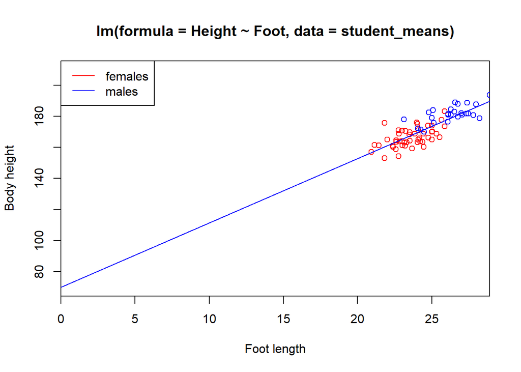

```r
plot_prediction(fit_Foot)
```

```r
# B.
(fit_Sex = lm(Height ~ Sex, data = student_means))
```

```
Call:
lm(formula = Height ~ Sex, data = student_means)

Coefficients:
(Intercept)      Sexmale
     166.33        14.91
```

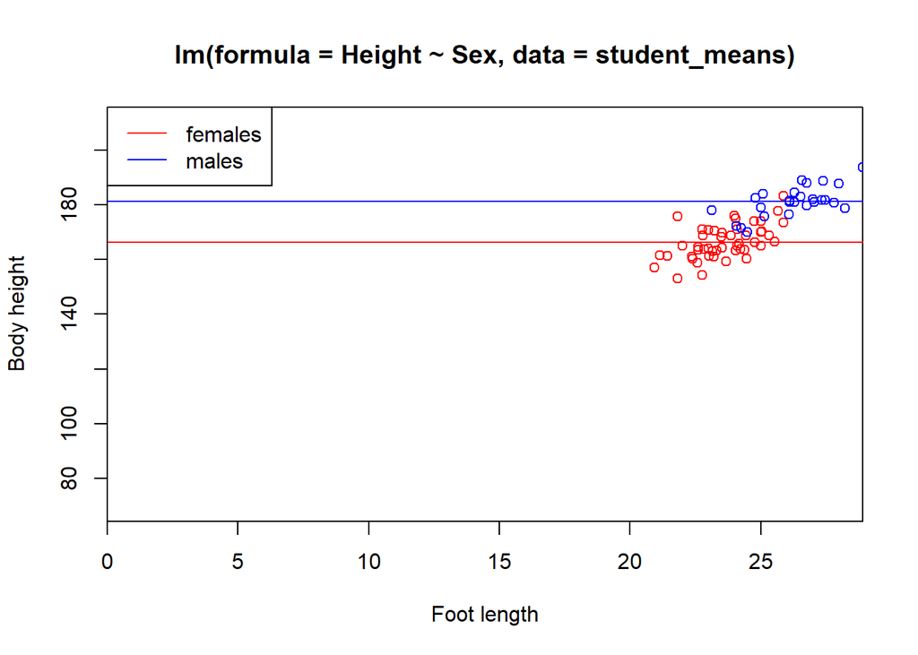

```r
plot_prediction(fit_Sex)
```

```r
# C.
(fit_Sex_Foot = lm(Height ~ Sex + Foot, data = student_means))
```

```
Call:
lm(formula = Height ~ Sex + Foot, data = student_means)

Coefficients:
(Intercept)      Sexmale         Foot
    102.159        7.687        2.720
```

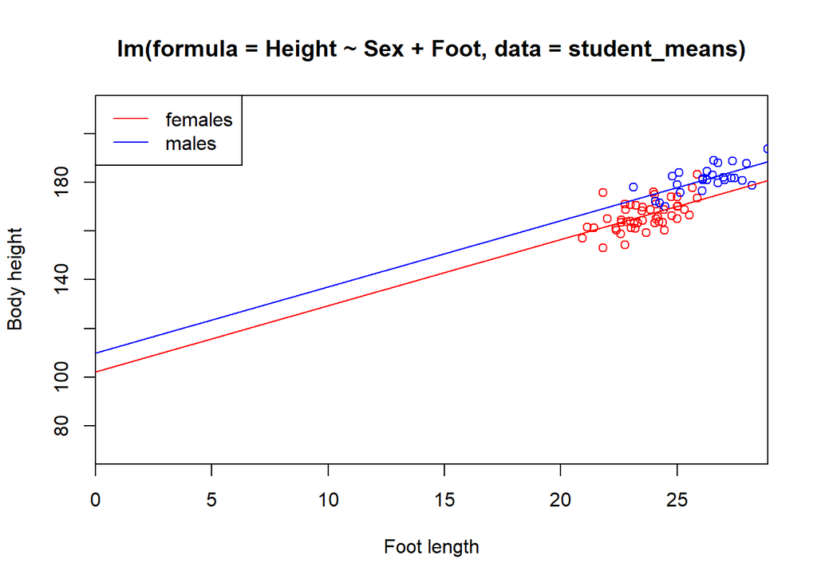

```r
plot_prediction(fit_Sex_Foot)
```

```r
# D.
(fit_Sex_Foot_int = lm(Height ~ Sex*Foot, data = student_means))
```

```
Call:
lm(formula = Height ~ Sex * Foot, data = student_means)

Coefficients:
 (Intercept)       Sexmale          Foot  Sexmale:Foot
     99.5486       14.5159        2.8302       -0.2713
```

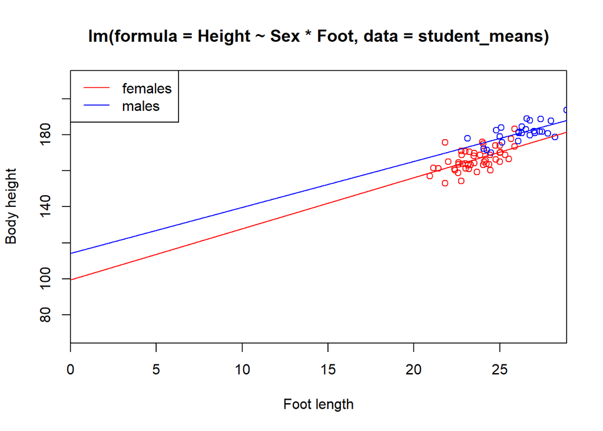

```r
plot_prediction(fit_Sex_Foot_int)
```

```r
# E.
(fit_Sex_FootCentered = lm(Height ~ Sex + I(Foot - mean(Foot)), data = student_means))
```

[output not shown]

```r
(fit_Sex_FootCentered = lm(Height ~ Sex + I(Foot - 24.44419), data = student_means))
```

```
Call:
lm(formula = Height ~ Sex + I(Foot - 24.44419), data = student_means)

Coefficients:
       (Intercept)             Sexmale  I(Foot - 24.44419)
           168.637               7.687               2.720
```

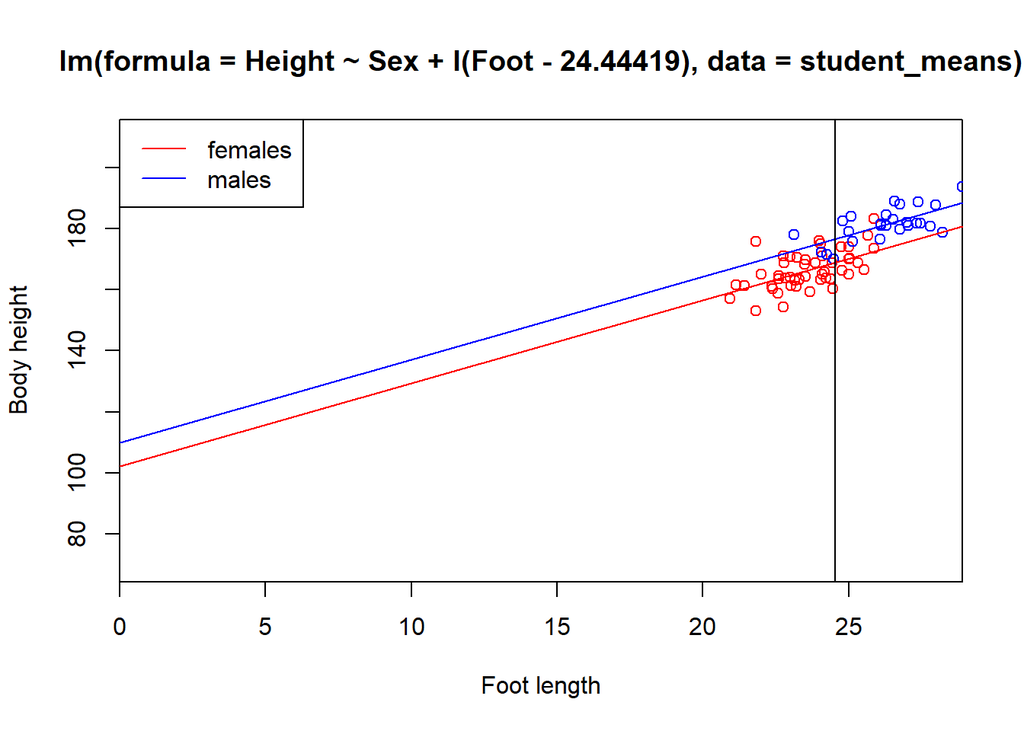

```r
plot_prediction(fit_Sex_FootCentered)
abline(v=mean(student_means$Foot))
```

In the last plot above, a vertical line has been drawn at mean foot length

6. Use `confint()` to get confidence intervals for the parameters in the above models and interpret them (what do they tell you?).

Both the point estimates and the confidence intervals of the parameters in each model are shown below.

```r
# A.
fit = fit_Foot
cbind(coef(fit), confint(fit))
```

```
                          2.5 %    97.5 %
(Intercept) 69.943170 52.729305 87.157036
Foot         4.142957  3.443126  4.842788
```

```r
# B.
fit = fit_Sex
cbind(coef(fit), confint(fit))
```

```
                          2.5 %    97.5 %
(Intercept) 166.33333 164.62101 168.04566
Sexmale      14.91154  12.02275  17.80032
```

```r
# C.
fit = fit_Sex_Foot
cbind(coef(fit), confint(fit))
```

```
                           2.5 %     97.5 %
(Intercept) 102.158600 81.711141 122.606059
Sexmale       7.686615  4.412032  10.961197
Foot          2.719588  1.855055   3.584122
```

```r
# D.
fit = fit_Sex_Foot_int
cbind(coef(fit), confint(fit))
```

```
                             2.5 %     97.5 %
(Intercept)  99.5486436  72.828094 126.269193
Sexmale      14.5159025 -30.186239  59.218044
Foot          2.8301929   1.699372   3.961013
Sexmale:Foot -0.2713173  -2.042430   1.499796
```

```r
# E.
fit = fit_Sex_FootCentered
cbind(coef(fit), confint(fit))
```

```
                                   2.5 %     97.5 %
(Intercept)        168.636737 167.071400 170.202074
Sexmale              7.686615   4.412032  10.961197
I(Foot - 24.44419)   2.719588   1.855055   3.584122
```

Some points to notice:

The confidence intervals for $\sigma$ are not computed by `confint()`. You may use bootstrapping to compute this confidence interval.